# pr5

Импортируем библиотеки для работы с набором данных pandas и numpy, а также библиотеку seaborn для построения графиков и библиотеку matplotlib.pyplot с упрощенными графиками.

```python
import pandas as pd
import numpy as np
# pip install seaborn
import seaborn as sns
import matplotlib.pyplot as plot

df = pd.read_csv('../pr4/vgsales/vgsales_14.csv')
df
```

|  | Rank | Name | Platform | Year | Genre | Publisher | NA_Sales | EU_Sales | JP_Sales | Other_Sales | Global_Sales |
| --- | --- | --- | --- | --- | --- | --- | --- | --- | --- | --- | --- |
| 0 | 10689 | Generator Rex: Agent of Providence | 3DS | 2011.0 | Action | Activision | 0.07 | 0.02 | 0.00 | 0.01 | 0.10 |
| 1 | 10856 | FIFA Street 3 | DS | 2008.0 | Sports | Electronic Arts | 0.07 | 0.02 | 0.00 | 0.01 | 0.09 |
| 2 | 12101 | Family Trainer: Treasure Adventure | Wii | 2010.0 | Sports | Namco Bandai Games | 0.00 | 0.06 | 0.00 | 0.01 | 0.07 |
| 3 | 2973 | Shark Tale | GBA | 2004.0 | Action | Activision | 0.49 | 0.18 | 0.00 | 0.01 | 0.68 |
| 4 | 8504 | Medieval Games | Wii | 2009.0 | Action | Vir2L Studios | 0.14 | 0.01 | 0.00 | 0.01 | 0.16 |
| ... | ... | ... | ... | ... | ... | ... | ... | ... | ... | ... | ... |
| 548 | 1004 | Star Wars: Starfighter | PS2 | 2001.0 | Simulation | Activision | 0.61 | 0.87 | 0.02 | 0.26 | 1.76 |
| 549 | 15227 | Umineko no Naku Koro ni: Majo to Suiri no Rinb... | PS3 | 2010.0 | Adventure | Alchemist | 0.00 | 0.00 | 0.02 | 0.00 | 0.02 |
| 550 | 15993 | Shinseiki Evangelion: Battle Orchestra Portable | PSP | 2009.0 | Fighting | Broccoli | 0.00 | 0.00 | 0.01 | 0.00 | 0.01 |
| 551 | 5753 | Cabela's Outdoor Adventures (2009) | Wii | 2009.0 | Sports | Activision Value | 0.29 | 0.00 | 0.00 | 0.02 | 0.31 |
| 552 | 15887 | GTI Club: Supermini Festa! | Wii | 2010.0 | Racing | Konami Digital Entertainment | 0.01 | 0.00 | 0.00 | 0.00 | 0.02 |

553 rows × 11 columns

Функция countplot() создаёт график, позволяющий продемонстрировать количество наблюдений в наборе данных в каждой категориальной ячейке с помощью столбцов.

Создадим график для категориального признака Platform из набора данных.

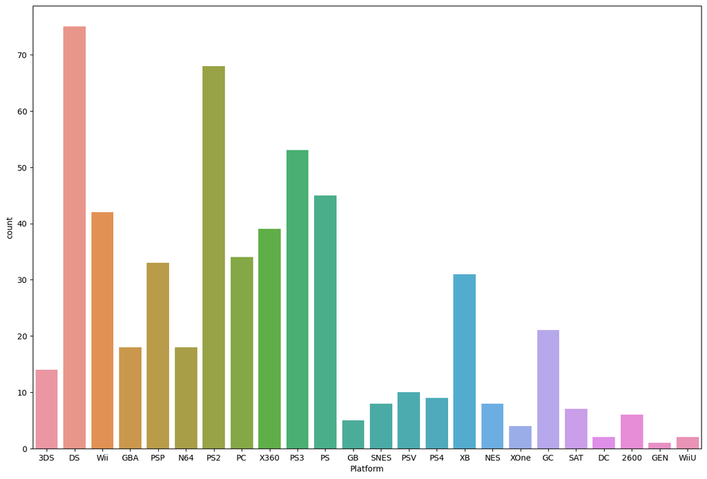

```python
graph = sns.countplot(x='Platform', data=df)
graph.figure.set_figwidth(15)
graph.figure.set_figheight(10)
```

Функция barplot() агрегирует данные по значениям категориальной переменной и применяет определённую функцию к значениям соответсвующих групп цифровой переменной.

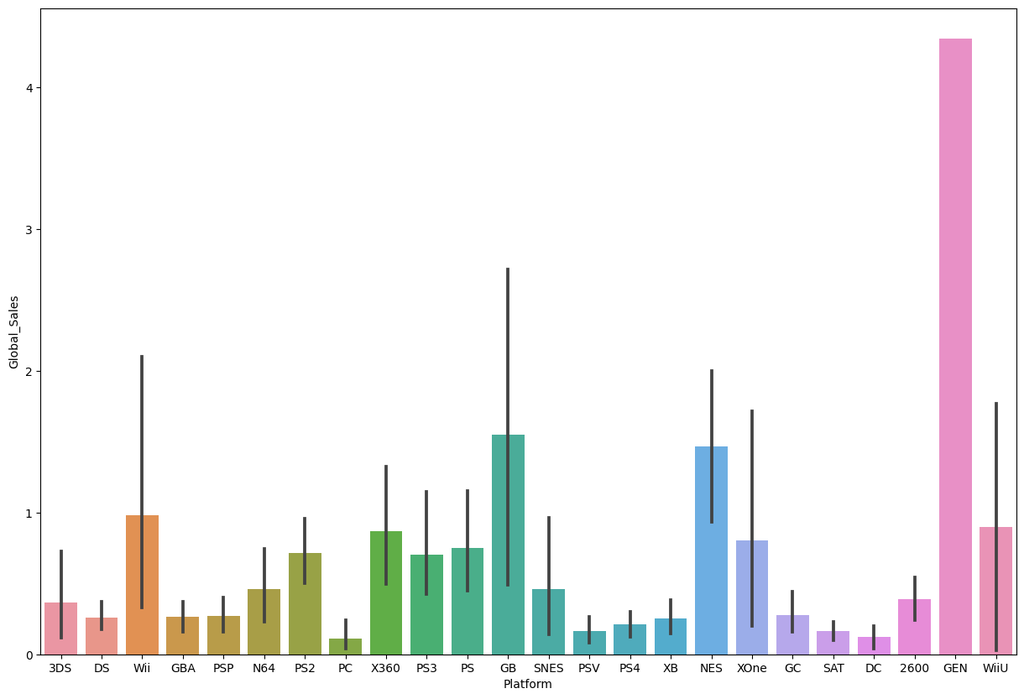

```python
plot.figure(figsize= (15,10))
sns.barplot(x=df['Platform'], y=df['Global_Sales'])
```

Функция boxplot() - диаграмма размаха.

Такой вид диаграммы в удобной форме показывает медиану (или, если нужно, среднее), нижний и верхний квартили, минимальное и максимальное значение выборки и выбросы.

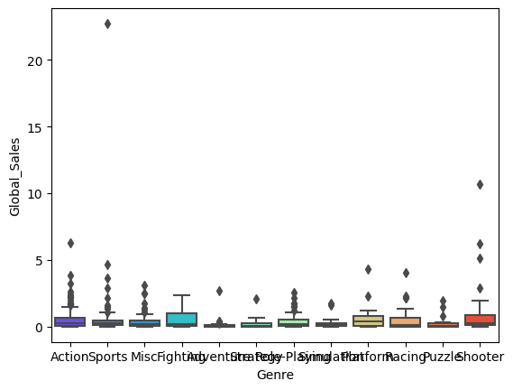

```python
sns.boxplot(x='Genre', y='Global_Sales', data=df, palette='rainbow')
```

Тепловая карта (heatmap()) - это метод визуализации данных, который показывает величину явления в виде цвета в двух измерениях.

Изменение цвета может быть вызвано оттенком или интенсивностью, что дает читателю очевидные визуальные подсказки о том, как явление группируется или изменяется в пространстве.

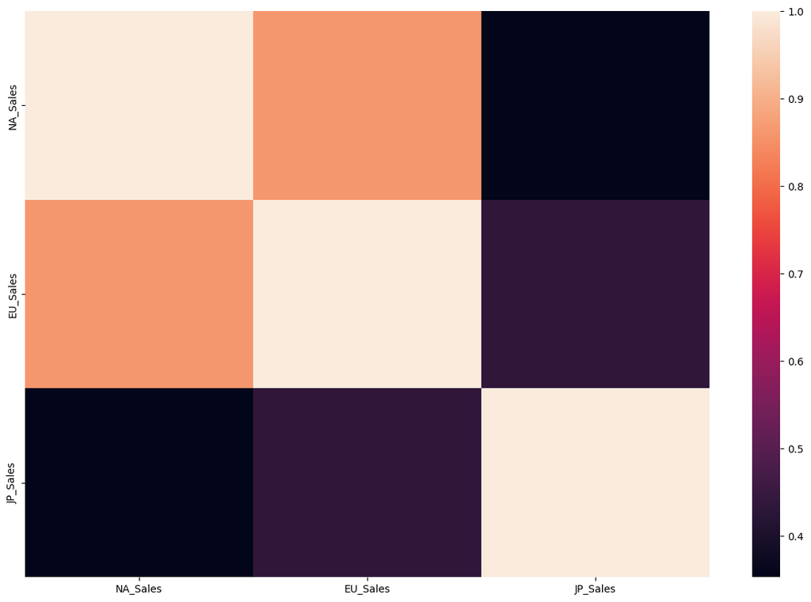

```python
plot.figure(figsize=(15,10))
text = df[["NA_Sales","EU_Sales","JP_Sales"]]
sns.heatmap(text.corr())
```

Функция pairplot() - построение попарных взаимосвязей в наборе данных.

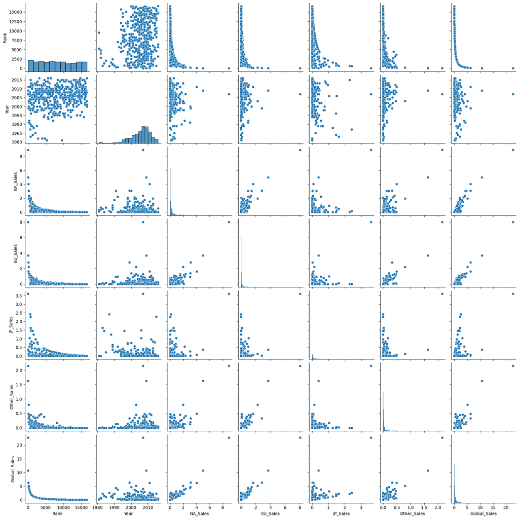

```python
sns.pairplot(df)
```

Функция pairgrid() - сетка подзаголовков для построения попарных взаимосвязей в наборе данных.

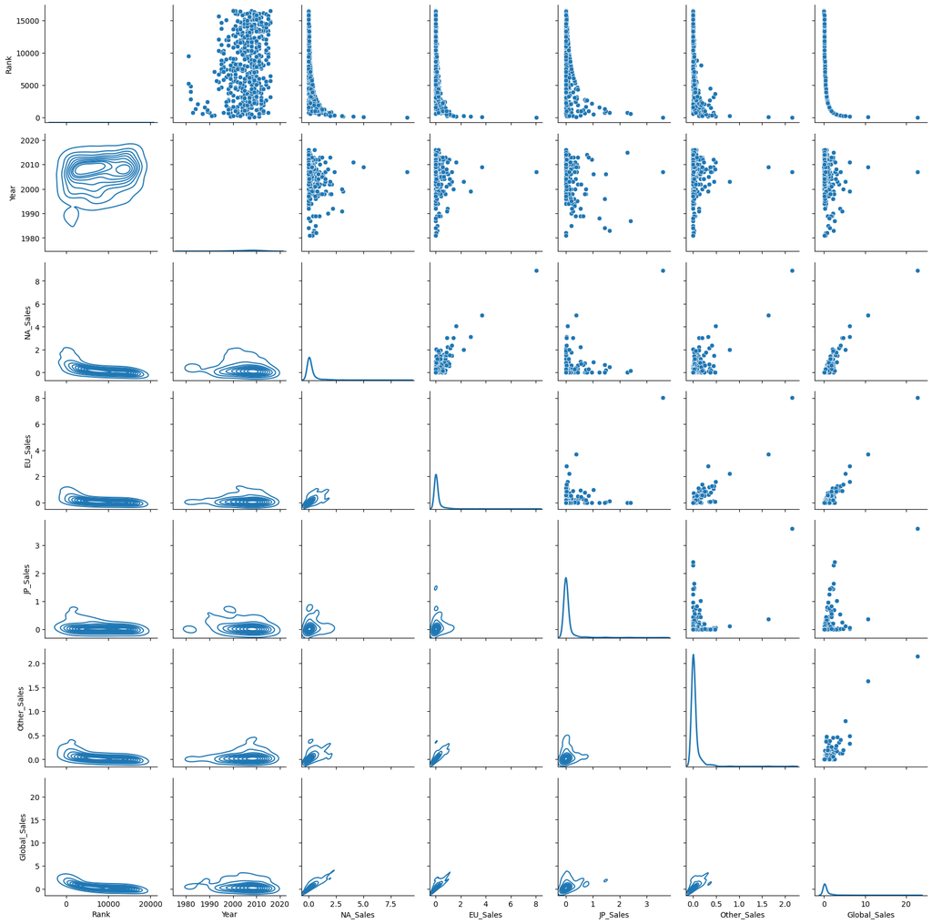

```python
graph = sns.PairGrid(df)
graph = graph.map_upper(sns.scatterplot)
graph = graph.map_lower(sns.kdeplot)
graph = graph.map_diag(sns.kdeplot, lw = 2)
```

```python
df_mini = df[["NA_Sales","EU_Sales","JP_Sales"]][::50]
df_mini
```

|  | NA_Sales | EU_Sales | JP_Sales |
| --- | --- | --- | --- |
| 0 | 0.07 | 0.02 | 0.00 |
| 50 | 0.00 | 0.00 | 0.05 |
| 100 | 0.00 | 0.01 | 0.00 |
| 150 | 4.05 | 1.62 | 0.07 |
| 200 | 0.00 | 0.00 | 0.04 |
| 250 | 3.03 | 0.91 | 0.26 |
| 300 | 0.00 | 0.00 | 0.20 |
| 350 | 0.09 | 0.26 | 0.05 |
| 400 | 0.05 | 0.02 | 0.00 |
| 450 | 0.01 | 0.02 | 0.00 |
| 500 | 0.12 | 0.01 | 0.00 |
| 550 | 0.00 | 0.00 | 0.01 |